# EDA - OpenData

Antonio Montilla - NEOLAND

28/11/2019

# Introducción

## Presentación

Esta práctica cubre de forma transversal la asignatura.

Las Prácticas 1 y 2 de la asignatura se plantean de una forma conjunta de modo que la Práctica 2 (Minería de Datos) será continuación de la 1.

El objetivo global de las dos prácticas consiste en seleccionar uno o varios juegos de datos, realizar las tareas de **preparación y análisis exploratorio** con el objetivo de disponer de datos listos para **aplicar algoritmos** de clustering, asociación y clasificación.

## Objetivos

La correcta asimilación de todos los aspectos trabajados durante el semestre.  
En esta práctica abordamos un caso real de minería de datos donde tenemos que poner en juego todos los conceptos trabajados. Hay que trabajar todo el ciclo de vida del proyecto. Desde el objetivo del proyecto hasta la implementación del conocimiento encontrado pasando por la preparación, limpieza de los datos, conocimiento de los datos, generación del modelo, interpretación y evaluación.

## Descripción de la Prácticas a realizar

## Recursos Básicos

Material docente proporcionado.

## Criterios de valoración

**Ejercicios prácticos**

Para todas las Prácticas es **necesario documentar** en cada apartado del ejercicio práctico que se ha hecho y como se ha hecho.

# Enunciado

Todo estudio analítico debe nacer de una necesidad por parte del Negocio o de una voluntad de dotarle de un conocimiento contenido en los datos y que solo podremos obtener a través de una colección de buenas prácticas basadas en la Minería de Datos.

El mundo de la analítica de datos se sustenta en 3 ejes:

1. Uno de ellos es el profundo **conocimiento** que deberíamos tener **del Negocio** al que tratamos de dar respuestas mediante los estudios analíticos.
2. El otro gran eje es sin duda las **capacidades analíticas** que seamos capaces de desplegar y en este sentido, las dos prácticas de esta asignatura pretenden que el estudiante realice un recorrido sólido por este segundo eje.
3. El tercer eje son los **Datos**. Las necesidades del Negocio deben concretarse con preguntas analíticas que a su vez sean viables responder a partir de los datos de que disponemos. La tarea de analizar los datos es sin duda importante, pero la tarea de identificarlos y obtenerlos va a ser para un analista un reto permanente.

Como **primera parte** del estudio analítico que nos disponemos a realizar, se pide al estudiante que complete los siguientes pasos:

1. Seleccionar un juego de datos y justificar su elección. El juego de datos deberá tener capacidades para que se le puedan aplicar algoritmos supervisados, algoritmos no supervisados y reglas de asociación.
2. Realizar un análisis exploratorio del juego de datos seleccionado.
3. Realizar tareas de limpieza y acondicionado para poder ser usado en procesos de modelado.
4. Realizar métodos de discretización

# Rúbrica

- Justificación de la elección del juego de datos donde se detalle el potencial analítico que se intuye. El estudiante deberá visitar los siguientes portales de datos abiertos para seleccionar su juego de datos:
- [Datos.gob.es](https://datos.gob.es/es/catalogo?q=&frequency=%7B%22type%22%3A+%22months%22%2C+%22value%22%3A+%221%22%7D&sort=score+desc%2C+metadata_modified+desc)
- [UCI Machine Learning](https://archive.ics.uci.edu/ml/datasets.php)
- [Datasets Wikipedia](https://en.wikipedia.org/wiki/List_of_datasets_for_machine-learning_research)
- [Datos abierto Madrid](https://datos.madrid.es/portal/site/egob/)
- [Datos abiertos Barcelona](https://opendata-ajuntament.barcelona.cat/ca/)
- [London Datastore](https://data.london.gov.uk/)
- [NYC OpenData](https://opendata.cityofnewyork.us/)
- Información extraída del análisis exploratorio. Distribuciones, correlaciones, anomalías,…
- Explicación clara de cualquier tarea de limpieza o acondicionado que se realiza. Justificando el motivo y mencionando las ventajas de la acción tomada.
- Realizar visualizaciones de las variables y de las observaciones
- Conclusiones de manera detallada
- Output en formato RMD y HTML desde la función Knit

# Práctica: Accidentes de Tráfico de la ciudad de Madrid

- Datos: registro de accidentes de tráfico en Madrid a lo largo del año 2019 (Enero- Octubre)
- Fuente: datos.madrid.es
- Justificación: la base de dato detalla información referente a los accidentes de tráfico en la ciudad de Madrid, incluyendo punto geográfico del incidente (i.e. calle, distrito), hora y fecha (i.e. dia, mes, temporada), tipo de vehículo (i.e. moto, particular, bus, pesado), personas involucradas, condiciones meteorológicas y grado de lesividad. Los datos son de un volumen considerable, actualizados por mes en función a los incidentes registrados y que, al ser prosesados y analisados, pudieran tener un gran valor para diversos grupos de la sociedad (incluyendo cuerpos de vigilancia de tráfico, policia, bomberos, hospitales y centros de atención médica, proveedores de seguros de coche, servicio de alquiler de coche y otros medios de transporte, usuarios privados, y administraciones publicas en general).

### 1. Cargando la base de datos directo de la fuente

```r
df_crash <- read.csv2('https://datos.madrid.es/egob/catalogo/300228-19-accidentes-trafico-detalle.csv', stringsAsFactors = FALSE, header = FALSE)
#Elimando el header que continie el DDBB para reemplazar por titulos limpios
df_crash <- df_crash[-1,]
names(df_crash) <- c('Expediente', 'Fecha', 'Hora', 'Calle', 'Num', 'Distrito', 'Tipo', 'Tiempo', 'Vehiculo', 'Persona', 'Edad', 'Sexo', 'Lesividad')
```

### 2. Creando un backup de la base de datos

```r
df_crash_backup <- df_crash
```

### 3. Exploración incial de la base de datos

```r
dim(df_crash)
```

```
## [1] 42443    13
```

```r
str(df_crash)
```

```
## 'data.frame':    42443 obs. of  13 variables:
##  $ Expediente: chr  "2019S000020" "2019S000017" "2019S000017" "2019S001812" ...
##  $ Fecha     : chr  "01/01/2019" "01/01/2019" "01/01/2019" "01/01/2019" ...
##  $ Hora      : chr  "23:30" "22:15" "22:15" "21:40" ...
##  $ Calle     : chr  "CALL. FUENCARRAL" "CALL. OCA / CALL. PINZON" "CALL. OCA / CALL. PINZON" "CALL. BAILEN / CUSTA. SAN VICENTE" ...
##  $ Num       : chr  "149" "-" "-" "-" ...
##  $ Distrito  : chr  "CHAMBER\xcd" "CARABANCHEL" "CARABANCHEL" "CENTRO" ...
##  $ Tipo      : chr  "Ca\xedda" "Colisi\xf3n fronto-lateral" "Colisi\xf3n fronto-lateral" "Colisi\xf3n fronto-lateral" ...
##  $ Tiempo    : chr  "Despejado" "Despejado" "Despejado" "Despejado" ...
##  $ Vehiculo  : chr  "Ciclomotor" "Turismo" "Ciclomotor" "Turismo" ...
##  $ Persona   : chr  "Conductor" "Conductor" "Conductor" "Conductor" ...
##  $ Edad      : chr  "DE 25 A 29 A\xd1OS" "DE 40 A 44 A\xd1OS" "DE 35 A 39 A\xd1OS" "DE 40 A 44 A\xd1OS" ...
##  $ Sexo      : chr  "Hombre" "Mujer" "Hombre" "Hombre" ...
##  $ Lesividad : chr  "01" "14" "03" "14" ...
```

```r
head(df_crash[1:5], n = 10)
```

```
##     Expediente      Fecha  Hora                             Calle Num
## 2  2019S000020 01/01/2019 23:30                  CALL. FUENCARRAL 149
## 3  2019S000017 01/01/2019 22:15          CALL. OCA / CALL. PINZON   -
## 4  2019S000017 01/01/2019 22:15          CALL. OCA / CALL. PINZON   -
## 5  2019S001812 01/01/2019 21:40 CALL. BAILEN / CUSTA. SAN VICENTE   -
## 6  2019S001812 01/01/2019 21:40 CALL. BAILEN / CUSTA. SAN VICENTE   -
## 7  2019S001812 01/01/2019 21:40 CALL. BAILEN / CUSTA. SAN VICENTE   -
## 8  2019S001336 01/01/2019 20:25            CALL. MESONERO ROMANOS   1
## 9  2019S001336 01/01/2019 20:25            CALL. MESONERO ROMANOS   1
## 10 2019S001336 01/01/2019 20:25            CALL. MESONERO ROMANOS   1
## 11 2019S001336 01/01/2019 20:25            CALL. MESONERO ROMANOS   1
```

```r
head(df_crash[6:10], n = 10)
```

```
##       Distrito                       Tipo    Tiempo   Vehiculo   Persona
## 2  CHAMBER\xcd                   Ca\xedda Despejado Ciclomotor Conductor
## 3  CARABANCHEL Colisi\xf3n fronto-lateral Despejado    Turismo Conductor
## 4  CARABANCHEL Colisi\xf3n fronto-lateral Despejado Ciclomotor Conductor
## 5       CENTRO Colisi\xf3n fronto-lateral Despejado    Turismo Conductor
## 6       CENTRO Colisi\xf3n fronto-lateral Despejado    Turismo Conductor
## 7       CENTRO Colisi\xf3n fronto-lateral Despejado    Turismo  Pasajero
## 8       CENTRO        Atropello a persona Despejado    Turismo Conductor
## 9       CENTRO        Atropello a persona Despejado    Turismo  Pasajero
## 10      CENTRO        Atropello a persona Despejado    Turismo  Pasajero
## 11      CENTRO        Atropello a persona Despejado    Turismo Peat\xf3n
```

```r
head(df_crash[11:13], n = 10)
```

```
##                  Edad   Sexo Lesividad
## 2  DE 25 A 29 A\xd1OS Hombre        01
## 3  DE 40 A 44 A\xd1OS  Mujer        14
## 4  DE 35 A 39 A\xd1OS Hombre        03
## 5  DE 40 A 44 A\xd1OS Hombre        14
## 6  DE 30 A 34 A\xd1OS  Mujer        07
## 7  DE 18 A 20 A\xd1OS  Mujer        14
## 8  DE 18 A 20 A\xd1OS Hombre        14
## 9  DE 30 A 34 A\xd1OS Hombre        14
## 10 DE 18 A 20 A\xd1OS  Mujer        14
## 11 DE 55 A 59 A\xd1OS Hombre        07
```

```r
tail(df_crash[1:5], n = 10)
```

```
##        Expediente      Fecha Hora                                   Calle
## 42435 2019S034404 31/10/2019 1:55 CALL. CEA BERMUDEZ / CALL. VALLEHERMOSO
## 42436 2019S034404 31/10/2019 1:55 CALL. CEA BERMUDEZ / CALL. VALLEHERMOSO
## 42437 2019S034404 31/10/2019 1:55 CALL. CEA BERMUDEZ / CALL. VALLEHERMOSO
## 42438 2019S034821 31/10/2019 1:40             PLAZA. CANOVAS DEL CASTILLO
## 42439 2019S034821 31/10/2019 1:40             PLAZA. CANOVAS DEL CASTILLO
## 42440 2019S034821 31/10/2019 1:40             PLAZA. CANOVAS DEL CASTILLO
## 42441 2019S034405 31/10/2019 1:37                            PASEO. PRADO
## 42442 2019S034405 31/10/2019 1:37                            PASEO. PRADO
## 42443 2019S034462 31/10/2019 0:55                   CALL. ISABELITA USERA
## 42444 2019S034462 31/10/2019 0:55                   CALL. ISABELITA USERA
##       Num
## 42435   -
## 42436   -
## 42437   -
## 42438   3
## 42439   3
## 42440   3
## 42441   2
## 42442   2
## 42443  57
## 42444  57
```

#### Primeras observaciones:

- La base de dato contiene 42.443 obersaciones con 13 columnas
- Las columnas contienen información de accidentes de tránsito en la ciudad Madrid a lo largo del 2019 (enero-Octubre), incluyendo hora, calle, distrito, condiciones meteorológicas, características de vehiculo y grado de lesividad.
- Todas las columnas son caracteres; el análisis conjunto de datos requerirá factorizar variables relevantes.
- Para mayor información de las columnas, ver https://datos.madrid.es/FWProjects/egob/Catalogo/Seguridad/Ficheros/Estructura_DS_Accidentes_trafico_desde_2019.pdf

#### Posibles preguntas exploratorias:

- Cuáles son los distritos de la ciudad donde se producen más accidentes?
- Y en términos de grado de lesividad?
- Se puede observar alguna calle en especial donde ocurren más accidentes?
- Cuáles son los dias del año en el que hay más accidentes, incluyendo en términos de lesividad?
- Y en términos de dia de la semana? los fines de semana son más fatales?
- A qué hora tienden a ocurrir los accidentes de tránsito? Mañana, tarde, noche o madrugada? Cuál hora es la más fatal?
- En cuál estación del año ha habido más accidentes de transitos?
- Cómo influye el tiempo en los accidentes de tránsito? Y en el número de fallecidos?
- Cuál tipo de vehículo es más propenso a accidentes? relación con grado de lesividad
- Cuáles grupos de edades han sufrido más accidentes? en cuáles grupos hay mayor incidencia de fallecimiento?
- Y en términos de sexo?
- Qué tipo de persona (e.g. conductor, testigo) es el más expuestos? En términos de testigo: cuántos han resultado en fallecimiento?

### 4. Limpieza: Explorar precensia de NAs en los datos

```r
colSums(is.na(df_crash))
```

```
## Expediente      Fecha       Hora      Calle        Num   Distrito
##          0          0          0          0          0          0
##       Tipo     Tiempo   Vehiculo    Persona       Edad       Sexo
##          0          0          0          0          0          0
##  Lesividad
##          0
```

#### La exploración sugiere no existen NAs en la dataset

### 5. Limpieza: missing values

```r
#Intentando distintos caracteres que pudieran contener obervaciones nulas
colSums(df_crash=="")
```

```
## Expediente      Fecha       Hora      Calle        Num   Distrito
##          0          0          0          0          4          5
##       Tipo     Tiempo   Vehiculo    Persona       Edad       Sexo
##          4       4245        156         26          0       4159
##  Lesividad
##      17615
```

```r
colSums(df_crash==" ")
```

```
## Expediente      Fecha       Hora      Calle        Num   Distrito
##          0          0          0          0          2          0
##       Tipo     Tiempo   Vehiculo    Persona       Edad       Sexo
##          0          0          0          0          0          0
##  Lesividad
##          0
```

```r
colSums(df_crash=="?")
```

```
## Expediente      Fecha       Hora      Calle        Num   Distrito
##          0          0          0          0          0          0
##       Tipo     Tiempo   Vehiculo    Persona       Edad       Sexo
##          0          0          0          0          0          0
##  Lesividad
##          0
```

```r
colSums(df_crash=="-")
```

```
## Expediente      Fecha       Hora      Calle        Num   Distrito
##          0          0          0          0      23159          0
##       Tipo     Tiempo   Vehiculo    Persona       Edad       Sexo
##          0          0          0          0          0          0
##  Lesividad
##          0
```

##### Las siguientes columnas contienen valores nulos:

- Num: 23.159 valores “-”, es decir sobre 55% de las observaciones.
- Lesividad: 17.615 valores vacios, alrededor de 41% de las observaciones. De acuerdo a la descripción de la base de datos, valores vacios corresponden a “sin asistencia sanitaria” que corresponde a la categoría 14. Solución: reemplazar por 14. Se debe explorar esta columna más detalladamente.
- Tiempo: 4.245 observaciones vacias, 10% de los datos.
- Sexo: 4.159 observaciones vacias, 10% de los datos.
- Vehículo: 156, 0.4% de los datos
- Distrito, persona, tipo: 0-30 valores nulos, insignificante en términos del tamaño de la base de dato.

### 6. Tratamiento de los datos

#### Num

- Columna que registra la ubicación exacta del accidente, i.e. número de la calle donde ocurrió.
- Con 55% de las observaciones con datos nulos (“-”) y en función a las posibles preguntas a explorar, se decide eliminar la columna de la base de dato.
- De igual manera, la columna *Expediente* (que registra el numero de expediente policial) se elimina

```r
#Eliminando las columnas _Num_ y _Expendiente_ y comprobando con head()
df_crash <- subset(df_crash, select = -Num)
df_crash <- subset(df_crash, select = -Expediente)
head(df_crash, n=5)
```

```
##        Fecha  Hora                             Calle    Distrito
## 2 01/01/2019 23:30                  CALL. FUENCARRAL CHAMBER\xcd
## 3 01/01/2019 22:15          CALL. OCA / CALL. PINZON CARABANCHEL
## 4 01/01/2019 22:15          CALL. OCA / CALL. PINZON CARABANCHEL
## 5 01/01/2019 21:40 CALL. BAILEN / CUSTA. SAN VICENTE      CENTRO
## 6 01/01/2019 21:40 CALL. BAILEN / CUSTA. SAN VICENTE      CENTRO
##                         Tipo    Tiempo   Vehiculo   Persona
## 2                   Ca\xedda Despejado Ciclomotor Conductor
## 3 Colisi\xf3n fronto-lateral Despejado    Turismo Conductor
## 4 Colisi\xf3n fronto-lateral Despejado Ciclomotor Conductor
## 5 Colisi\xf3n fronto-lateral Despejado    Turismo Conductor
## 6 Colisi\xf3n fronto-lateral Despejado    Turismo Conductor
##                 Edad   Sexo Lesividad
## 2 DE 25 A 29 A\xd1OS Hombre        01
## 3 DE 40 A 44 A\xd1OS  Mujer        14
## 4 DE 35 A 39 A\xd1OS Hombre        03
## 5 DE 40 A 44 A\xd1OS Hombre        14
## 6 DE 30 A 34 A\xd1OS  Mujer        07
```

#### Vehiculo

- 156 datos missing.
- 70% de datos categoria ‘turismo’. Usar moda para datos vacios

```r
df_crash$Vehiculo[df_crash$Vehiculo==""] = 'Turismo'
table(df_crash$Vehiculo)
```

```
##
##                   Autob\xfas        Autob\xfas articulado
##                         1194                           75
##                 Autocaravana                    Bicicleta
##                           12                          779
##          Cami\xf3n r\xedgido                     Caravana
##                          940                            1
##                        Ciclo                   Ciclomotor
##                           16                          638
##           Cuadriciclo ligero        Cuadriciclo no ligero
##                           12                           12
##                    Furgoneta          Maquinaria de obras
##                         2592                           99
##      Microb\xfas <=17 plazas          Motocicleta > 125cc
##                            2                         3129
##      Motocicleta hasta 125cc Otros veh\xedculos con motor
##                         1843                          302
## Otros veh\xedculos sin motor                     Remolque
##                            8                            3
##                 Semiremolque              Sin especificar
##                            5                           34
##                 Todo terreno              Tractocami\xf3n
##                          539                          164
##                   Tranv\xeda                      Turismo
##                            1                        29955
##       Veh\xedculo articulado
##                           88
```

```r
prop.table(table(df_crash$Vehiculo))
```

```
##
##                   Autob\xfas        Autob\xfas articulado
##                 2.813185e-02                 1.767076e-03
##                 Autocaravana                    Bicicleta
##                 2.827321e-04                 1.835403e-02
##          Cami\xf3n r\xedgido                     Caravana
##                 2.214735e-02                 2.356101e-05
##                        Ciclo                   Ciclomotor
##                 3.769762e-04                 1.503193e-02
##           Cuadriciclo ligero        Cuadriciclo no ligero
##                 2.827321e-04                 2.827321e-04
##                    Furgoneta          Maquinaria de obras
##                 6.107014e-02                 2.332540e-03
##      Microb\xfas <=17 plazas          Motocicleta > 125cc
##                 4.712202e-05                 7.372240e-02
##      Motocicleta hasta 125cc Otros veh\xedculos con motor
##                 4.342294e-02                 7.115425e-03
## Otros veh\xedculos sin motor                     Remolque
##                 1.884881e-04                 7.068303e-05
##                 Semiremolque              Sin especificar
##                 1.178051e-04                 8.010744e-04
##                 Todo terreno              Tractocami\xf3n
##                 1.269939e-02                 3.864006e-03
##                   Tranv\xeda                      Turismo
##                 2.356101e-05                 7.057701e-01
##       Veh\xedculo articulado
##                 2.073369e-03
```

#### Otras: Distrito, persona, tipo

- 0-30 valores nulos.
- Eliminar observaciones vacias: 1) volver NAs, 2) eliminar NAs

```r
df_crash$Distrito[df_crash$Distrito==""] = NA
df_crash$Persona[df_crash$Persona==""] = NA
df_crash$Tipo[df_crash$Tipo==""] = NA
df_crash <- df_crash[complete.cases(df_crash$Distrito), ]
df_crash <- df_crash[complete.cases(df_crash$Persona), ]
df_crash <- df_crash[complete.cases(df_crash$Tipo), ]
colSums(is.na(df_crash))
```

```
##     Fecha      Hora     Calle  Distrito      Tipo    Tiempo  Vehiculo
##         0         0         0         0         0         0         0
##   Persona      Edad      Sexo Lesividad
##         0         0         0         0
```

#### Lesividad

La columna toma los valores:

- 01-02 y 05-07: leve, con distintos grados de asistencia médica
- 03: grave
- 04: fatal (fallecido)
- 14: sin asistencia
- ’’: sin asistancia
- 77: se deconoce

Observando la distribución de la columna

```r
table(df_crash$Lesividad)
```

```
##
##          01    02    03    04    05    06    07    14    77
## 17594  1067  1803   417    26   593  1259  5870 13781     1
```

Acciones a tomar:

- Remplazar los missing por 14 (‘sin asistencia’)
- Eliminar la única observación con valor 77

```r
df_crash$Lesividad[df_crash$Lesividad==""] = "14"
df_crash <- df_crash[df_crash$Lesividad!="77", ]
table(df_crash$Lesividad)
```

```
##
##    01    02    03    04    05    06    07    14
##  1067  1803   417    26   593  1259  5870 31375
```

#### Tiempo

```r
table(df_crash$Tiempo)
```

```
##
##                       Despejado      Granizando Lluvia d\xe9bil
##            4241           34467              14            1825
##  LLuvia intensa         Nevando         Nublado    Se desconoce
##             377               2             943             541
```

```r
prop.table(table(df_crash$Tiempo))
```

```
##
##                       Despejado      Granizando Lluvia d\xe9bil
##    1.000000e-01    8.127093e-01    3.301108e-04    4.303230e-02
##  LLuvia intensa         Nevando         Nublado    Se desconoce
##    8.889413e-03    4.715869e-05    2.223532e-02    1.275643e-02
```

- 10% de los datos están vacios,
- 1.3% de los datos “se desconoce”

Acciones a tomar:

- Por ahora reemplazar los vacios por “Se desconoce”
- Al factorizar las columnas, mostrar tabla de correlaciones con otras variables para determinar si se puede estimar con información en otras columnas (en pasos posteriores).

```r
df_crash$Tiempo[df_crash$Tiempo==""] = "Se desconoce"
table(df_crash$Tiempo)
```

```
##
##       Despejado      Granizando Lluvia d\xe9bil  LLuvia intensa
##           34467              14            1825             377
##         Nevando         Nublado    Se desconoce
##               2             943            4782
```

#### Sexo

- 4.159 observaciones vacias, 10% de los datos.
- Reemplazar con NAs para poder excluir al momento del análisis conjunto.

```r
df_crash$Sexo[df_crash$Sexo==""] = NA
table(df_crash$Sexo)
```

```
##
## Hombre  Mujer
##  25825  12435
```

```r
prop.table(table(df_crash$Sexo))
```

```
##
##    Hombre     Mujer
## 0.6749869 0.3250131
```

```r
colSums(is.na(df_crash))
```

```
##     Fecha      Hora     Calle  Distrito      Tipo    Tiempo  Vehiculo
##         0         0         0         0         0         0         0
##   Persona      Edad      Sexo Lesividad
##         0         0      4150         0
```

#### Edad

```r
df_crash$Edad[df_crash$Edad=="DESCONOCIDA"] = "DE 40 A 44 A\xd1OS"
table(df_crash$Edad)
```

```
##
##    DE 0 A 5 A\xd1OS  DE 10 A 14 A\xd1OS  DE 15 A 17 A\xd1OS
##                 436                 417                 285
##  DE 18 A 20 A\xd1OS  DE 21 A 24 A\xd1OS  DE 25 A 29 A\xd1OS
##                1273                2662                4567
##  DE 30 A 34 A\xd1OS  DE 35 A 39 A\xd1OS  DE 40 A 44 A\xd1OS
##                4472                4590                9135
##  DE 45 A 49 A\xd1OS  DE 50 A 54 A\xd1OS  DE 55 A 59 A\xd1OS
##                4051                3508                2676
##    DE 6 A 9 A\xd1OS  DE 60 A 64 A\xd1OS  DE 65 A 69 A\xd1OS
##                 324                1624                 831
##  DE 70 A 74 A\xd1OS MAYOR DE 74 A\xd1OS
##                 594                 965
```

### 7. Creación de nuevos atributos y agrupaciones

#### Lesividad: agrupación

Crear nueva variable *LesividadF* que agrupe las observaciones con asistencia leve (valores 01-02, 05-07 y sin asistencia) como ‘leve’, ‘grave’ (03), y fallecidos (04) como ‘Fatal’.

```r
df_crash$LesividadF <- ifelse(df_crash$Lesividad =='03', "grave", "leve")
df_crash$LesividadF[df_crash$Lesividad=="04"] = "fatal"
table(df_crash$LesividadF)
```

```
##
## fatal grave  leve
##    26   417 41967
```

```r
table(df_crash$Lesividad)
```

```
##
##    01    02    03    04    05    06    07    14
##  1067  1803   417    26   593  1259  5870 31375
```

#### Calendario: dia de la semana

- A partir de la columna *fecha* crear nueva columna *dia* que contenga dia de la semana
- A partir de *dia* crear una nueva columna *finde* que tome 1 si dia es sábado o domingo

```r
library(lubridate)
df_crash$Date1 <- parse_date_time(df_crash$Fecha, orders = c("ymd", "dmy", "mdy"))
df_crash$Dia <- weekdays(df_crash$Date1)
table(df_crash$Dia)
```

```
##
##    Friday    Monday  Saturday    Sunday  Thursday   Tuesday Wednesday
##      7186      5712      5251      4931      6345      6451      6534
```

```r
df_crash$Finde <- ifelse(df_crash$Dia =='Saturday', 1, 0)
df_crash$Finde[df_crash$Dia=="Sunday"] = 1
table(df_crash$Finde)
```

```
##
##     0     1
## 32228 10182
```

- Crear una columna con el mes del año en que ocurrió el accidente

```r
df_crash$Mes <- month(df_crash$Date1)
table(df_crash$Mes)
```

```
##
##    1    2    3    4    5    6    7    8    9   10
## 4136 4312 4474 4317 4525 4462 4188 2736 4163 5097
```

- Temporada: crear una columna con la temporada (invierno, primavera, verano) a partir de *mes*

```r
df_crash$Season <- ifelse(df_crash$Mes<=3, "Invierno", "Primavera")
df_crash$Season[df_crash$Mes>6] = "Verano"
df_crash$Season[df_crash$Mes>9] = "Octubre"
table(df_crash$Season)
```

```
##
##  Invierno   Octubre Primavera    Verano
##     12922      5097     13304     11087
```

#### Vehículo: Agrupacion

Agrupar en nueva columna con categoria:

- ‘Turismo’ (Turismo, Cuadriciclo, Cuadriciclo no ligero).
- ‘Furgoneta’ (Furgoneta, Todo terreno).
- ‘Moto’ (Ciclomotor, Motocicleta > 125cc, Motocicleta hasta 125cc).
- ‘Bici’ (Bicicleta, Ciclo).
- Bus (Autob, Autobarticulado, Caravana, Autocaravana, Microb<=17 plazas).
- ‘Pesado’ (Cami3n r, Maquinaria de obras, Remolque, Semiremolque, Tractocami3n, Veharticulado, Tranv).
- Otros (Otros vehcon motor, Otros vehsin motor, Sin especificar)

```r
df_crash$VehiculoT <- ifelse(df_crash$Vehiculo=="Turismo", "Turismo", "Pesado")
df_crash$VehiculoT[df_crash$Vehiculo=="Furgoneta"] = "Furgoneta"
df_crash$VehiculoT[df_crash$Vehiculo=="Todo terreno"] = "Furgoneta"
df_crash$VehiculoT[df_crash$Vehiculo=="Ciclomotor"] = "Moto"
df_crash$VehiculoT[df_crash$Vehiculo=="Motocicleta > 125cc"] = "Moto"
df_crash$VehiculoT[df_crash$Vehiculo=="Motocicleta hasta 125cc"] = "Moto"
df_crash$VehiculoT[df_crash$Vehiculo=="Bicicleta"] = "Bici"
df_crash$VehiculoT[df_crash$Vehiculo=="Ciclo"] = "Bici"
df_crash$VehiculoT[df_crash$Vehiculo=="Autob\xfas"] = "Bus"
df_crash$VehiculoT[df_crash$Vehiculo=="Autob\xfas articulado"] = "Bus"
df_crash$VehiculoT[df_crash$Vehiculo=="Caravana"] = "Bus"
df_crash$VehiculoT[df_crash$Vehiculo=="Autocaravana"] = "Bus"
df_crash$VehiculoT[df_crash$Vehiculo=="Microb\xfas <=17 plazas"] = "Bus"
df_crash$VehiculoT[df_crash$Vehiculo=="Otros veh\xedculos con motor"] = "Otros"
df_crash$VehiculoT[df_crash$Vehiculo=="Sin especificar"] = "Otros"
df_crash$VehiculoT[df_crash$Vehiculo=="Otros veh\xedculos sin motor"] = "Otros"
table(df_crash$VehiculoT)
```

```
##
##      Bici       Bus Furgoneta      Moto     Otros    Pesado   Turismo
##       795      1282      3129      5607       344      1322     29931
```

#### Edad: Agrupacion

Crear grupos de edades: nino (0-14), joven (15-24), joven adulto (25-35), adulto (35-65), mayor (>65)

```r
table(df_crash$Edad)
```

```
##
##    DE 0 A 5 A\xd1OS  DE 10 A 14 A\xd1OS  DE 15 A 17 A\xd1OS
##                 436                 417                 285
##  DE 18 A 20 A\xd1OS  DE 21 A 24 A\xd1OS  DE 25 A 29 A\xd1OS
##                1273                2662                4567
##  DE 30 A 34 A\xd1OS  DE 35 A 39 A\xd1OS  DE 40 A 44 A\xd1OS
##                4472                4590                9135
##  DE 45 A 49 A\xd1OS  DE 50 A 54 A\xd1OS  DE 55 A 59 A\xd1OS
##                4051                3508                2676
##    DE 6 A 9 A\xd1OS  DE 60 A 64 A\xd1OS  DE 65 A 69 A\xd1OS
##                 324                1624                 831
##  DE 70 A 74 A\xd1OS MAYOR DE 74 A\xd1OS
##                 594                 965
```

```r
df_crash$EdadF <- ifelse(df_crash$Edad=="DE 0 A 5 A\xd1OS", "nino", "adulto")
df_crash$EdadF[df_crash$Edad=="DE 10 A 14 A\xd1OS"] = "nino"
df_crash$EdadF[df_crash$Edad=="DE 6 A 9 A\xd1OS"] = "nino"
df_crash$EdadF[df_crash$Edad=="DE 15 A 17 A\xd1OS"] = "joven"
df_crash$EdadF[df_crash$Edad=="DE 18 A 20 A\xd1OS"] = "joven"
df_crash$EdadF[df_crash$Edad=="DE 21 A 24 A\xd1OS"] = "joven"
df_crash$EdadF[df_crash$Edad=="DE 25 A 29 A\xd1OS"] = "joven adulto"
df_crash$EdadF[df_crash$Edad=="DE 30 A 34 A\xd1OS"] = "joven adulto"
df_crash$EdadF[df_crash$Edad=="DE 65 A 69 A\xd1OS"] = "mayor"
df_crash$EdadF[df_crash$Edad=="DE 70 A 74 A\xd1OS"] = "mayor"
df_crash$EdadF[df_crash$Edad=="MAYOR DE 74 A\xd1OS"] = "mayor"
table(df_crash$EdadF)
```

```
##
##       adulto        joven joven adulto        mayor         nino
##        25584         4220         9039         2390         1177
```

```r
table(df_crash$Distrito)
```

```
##
##          ARGANZUELA             BARAJAS         CARABANCHEL
##                1852                 911                2777
##              CENTRO        CHAMART\xcdN         CHAMBER\xcd
##                2339                3161                2191
##       CIUDAD LINEAL FUENCARRAL-EL PARDO           HORTALEZA
##                2710                1996                1677
##              LATINA     MONCLOA-ARAVACA           MORATALAZ
##                2071                2185                1265
##  PUENTE DE VALLECAS              RETIRO           SALAMANCA
##                3279                2216                3229
## SAN BLAS-CANILLEJAS           TETU\xc1N               USERA
##                2329                1929                1464
##        VIC\xc1LVARO   VILLA DE VALLECAS          VILLAVERDE
##                 559                1054                1216
```

### 8. Discretrizando las variables

```r
apply(df_crash, MARGIN = 2, FUN = function(x) length(unique(x)))
```

```
##      Fecha       Hora      Calle   Distrito       Tipo     Tiempo
##        304       1173       9002         21         13          7
##   Vehiculo    Persona       Edad       Sexo  Lesividad LesividadF
##         25          3         17          3          8          3
##      Date1        Dia      Finde        Mes     Season  VehiculoT
##        304          7          2         10          4          7
##      EdadF
##          5
```

Las variables a discrtizar: Distrito, Tiempo, Persona, Sexo, LesividadF, Dia, Finde, Mes, Season, VehiculoT, EdadF

```r
cols1 <- c("Distrito", "Tiempo", "Persona", "Sexo", "LesividadF", "Dia", "Finde", "Mes", "Season", "VehiculoT", "EdadF")
for (i in cols1){
  df_crash[,i] = as.factor(df_crash[,i])
}
str(df_crash)
```

```
## 'data.frame':    42410 obs. of  19 variables:
##  $ Fecha     : chr  "01/01/2019" "01/01/2019" "01/01/2019" "01/01/2019" ...
##  $ Hora      : chr  "23:30" "22:15" "22:15" "21:40" ...
##  $ Calle     : chr  "CALL. FUENCARRAL" "CALL. OCA / CALL. PINZON" "CALL. OCA / CALL. PINZON" "CALL. BAILEN / CUSTA. SAN VICENTE" ...
##  $ Distrito  : Factor w/ 21 levels "ARGANZUELA","BARAJAS",..: 6 3 3 4 4 4 4 4 4 4 ...
##  $ Tipo      : chr  "Ca\xedda" "Colisi\xf3n fronto-lateral" "Colisi\xf3n fronto-lateral" "Colisi\xf3n fronto-lateral" ...
##  $ Tiempo    : Factor w/ 7 levels "Despejado","Granizando",..: 1 1 1 1 1 1 1 1 1 1 ...
##  $ Vehiculo  : chr  "Ciclomotor" "Turismo" "Ciclomotor" "Turismo" ...
##  $ Persona   : Factor w/ 3 levels "Conductor","Pasajero",..: 1 1 1 1 1 2 1 2 2 3 ...
##  $ Edad      : chr  "DE 25 A 29 A\xd1OS" "DE 40 A 44 A\xd1OS" "DE 35 A 39 A\xd1OS" "DE 40 A 44 A\xd1OS" ...
##  $ Sexo      : Factor w/ 2 levels "Hombre","Mujer": 1 2 1 1 2 2 1 1 2 1 ...
##  $ Lesividad : chr  "01" "14" "03" "14" ...
##  $ LesividadF: Factor w/ 3 levels "fatal","grave",..: 3 3 2 3 3 3 3 3 3 3 ...
##  $ Date1     : POSIXct, format: "2019-01-01" "2019-01-01" ...
##  $ Dia       : Factor w/ 7 levels "Friday","Monday",..: 6 6 6 6 6 6 6 6 6 6 ...
##  $ Finde     : Factor w/ 2 levels "0","1": 1 1 1 1 1 1 1 1 1 1 ...
##  $ Mes       : Factor w/ 10 levels "1","2","3","4",..: 1 1 1 1 1 1 1 1 1 1 ...
##  $ Season    : Factor w/ 4 levels "Invierno","Octubre",..: 1 1 1 1 1 1 1 1 1 1 ...
##  $ VehiculoT : Factor w/ 7 levels "Bici","Bus","Furgoneta",..: 4 7 4 7 7 7 7 7 7 7 ...
##  $ EdadF     : Factor w/ 5 levels "adulto","joven",..: 3 1 1 1 3 2 2 3 2 1 ...
```

Finalmente, por cuestiones de limpieza, se crea una nueva dataframe con las columnas que se utilizarán en el análisis conjunto de los datos

```r
df_crashF <- data.frame(df_crash$Hora, df_crash$Calle, df_crash$Distrito, df_crash$Tiempo, df_crash$Persona, df_crash$Sexo, df_crash$LesividadF, df_crash$Date1, df_crash$Dia, df_crash$Finde, df_crash$Mes, df_crash$Season, df_crash$VehiculoT, df_crash$EdadF)
str(df_crashF)
```

```
## 'data.frame':    42410 obs. of  14 variables:
##  $ df_crash.Hora      : Factor w/ 1173 levels "0:00","0:01",..: 866 797 797 765 765 765 699 699 699 699 ...
##  $ df_crash.Calle     : Factor w/ 9002 levels " 16 XC 96 TUNEL CALLE 30",..: 4138 5652 5652 2926 2926 2926 5403 5403 5403 5403 ...
##  $ df_crash.Distrito  : Factor w/ 21 levels "ARGANZUELA","BARAJAS",..: 6 3 3 4 4 4 4 4 4 4 ...
##  $ df_crash.Tiempo    : Factor w/ 7 levels "Despejado","Granizando",..: 1 1 1 1 1 1 1 1 1 1 ...
##  $ df_crash.Persona   : Factor w/ 3 levels "Conductor","Pasajero",..: 1 1 1 1 1 2 1 2 2 3 ...
##  $ df_crash.Sexo      : Factor w/ 2 levels "Hombre","Mujer": 1 2 1 1 2 2 1 1 2 1 ...
##  $ df_crash.LesividadF: Factor w/ 3 levels "fatal","grave",..: 3 3 2 3 3 3 3 3 3 3 ...
##  $ df_crash.Date1     : POSIXct, format: "2019-01-01" "2019-01-01" ...
##  $ df_crash.Dia       : Factor w/ 7 levels "Friday","Monday",..: 6 6 6 6 6 6 6 6 6 6 ...
##  $ df_crash.Finde     : Factor w/ 2 levels "0","1": 1 1 1 1 1 1 1 1 1 1 ...
##  $ df_crash.Mes       : Factor w/ 10 levels "1","2","3","4",..: 1 1 1 1 1 1 1 1 1 1 ...
##  $ df_crash.Season    : Factor w/ 4 levels "Invierno","Octubre",..: 1 1 1 1 1 1 1 1 1 1 ...
##  $ df_crash.VehiculoT : Factor w/ 7 levels "Bici","Bus","Furgoneta",..: 4 7 4 7 7 7 7 7 7 7 ...
##  $ df_crash.EdadF     : Factor w/ 5 levels "adulto","joven",..: 3 1 1 1 3 2 2 3 2 1 ...
```

### 9. Análisis Conjunto de los Datos

#### Punto Geográfico

##### Cuáles son los distritos de la ciudad donde se producen más accidentes?

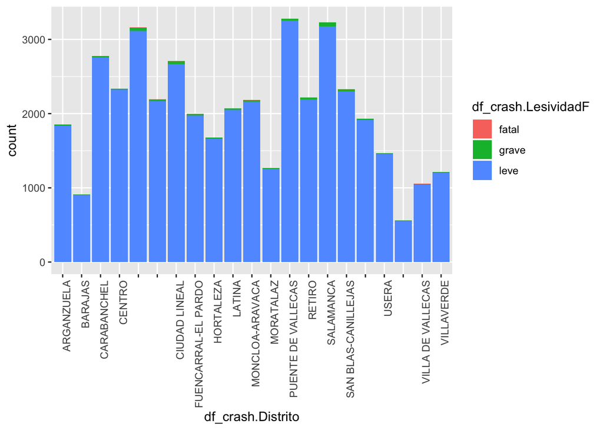

```r
filas = dim(df_crashF)[1]
q <- ggplot(data=df_crashF[1:filas,], aes(x=df_crash.Distrito, fill=df_crash.LesividadF))+geom_bar()
q + theme(axis.text.x = element_text(angle = 90, hjust = 1))
```

- Puente de Vallecas, Salamanca, Chamartin, Carabanchel, y la ciudad Lineal son los distritos de Madrid donde más se han registrado accidentes de tráfico en el 2019.

##### Y en términos de grado de lesividad?

```r
# Tabla de frecuencia absoluta
prop.table(table(df_crashF$df_crash.LesividadF))
```

```
##
##       fatal       grave        leve
## 0.000613063 0.009832587 0.989554350
```

```r
table(df_crashF$df_crash.LesividadF)
```

```
##
## fatal grave  leve
##    26   417 41967
```

```r
t1<-table(df_crashF[1:filas,]$df_crash.Distrito, df_crashF[1:filas,]$df_crash.LesividadF)

t<-table(df_crashF[1:filas,]$df_crash.Distrito, df_crashF[1:filas,]$df_crash.LesividadF)
for (i in 1:dim(t)[1]){
    t[i,]<-t[i,]/sum(t[i,])*100
}
t1
```

```
##
##                       fatal grave leve
##   ARGANZUELA              1    18 1833
##   BARAJAS                 0     3  908
##   CARABANCHEL             0    17 2760
##   CENTRO                  0    15 2324
##   CHAMART\xcdN            2    46 3113
##   CHAMBER\xcd             2    23 2166
##   CIUDAD LINEAL           3    38 2669
##   FUENCARRAL-EL PARDO     2    20 1974
##   HORTALEZA               0    17 1660
##   LATINA                  1    17 2053
##   MONCLOA-ARAVACA         5    18 2162
##   MORATALAZ               0     9 1256
##   PUENTE DE VALLECAS      2    25 3252
##   RETIRO                  3    24 2189
##   SALAMANCA               1    51 3177
##   SAN BLAS-CANILLEJAS     2    25 2302
##   TETU\xc1N               0    14 1915
##   USERA                   0    12 1452
##   VIC\xc1LVARO            0     1  558
##   VILLA DE VALLECAS       2    10 1042
##   VILLAVERDE              0    14 1202
```

```r
t
```

```
##
##                             fatal       grave        leve
##   ARGANZUELA           0.05399568  0.97192225 98.97408207
##   BARAJAS              0.00000000  0.32930845 99.67069155
##   CARABANCHEL          0.00000000  0.61217141 99.38782859
##   CENTRO               0.00000000  0.64129970 99.35870030
##   CHAMART\xcdN         0.06327112  1.45523568 98.48149320
##   CHAMBER\xcd          0.09128252  1.04974897 98.85896851
##   CIUDAD LINEAL        0.11070111  1.40221402 98.48708487
##   FUENCARRAL-EL PARDO  0.10020040  1.00200401 98.89779559
##   HORTALEZA            0.00000000  1.01371497 98.98628503
##   LATINA               0.04828585  0.82085949 99.13085466
##   MONCLOA-ARAVACA      0.22883295  0.82379863 98.94736842
##   MORATALAZ            0.00000000  0.71146245 99.28853755
##   PUENTE DE VALLECAS   0.06099421  0.76242757 99.17657823
##   RETIRO               0.13537906  1.08303249 98.78158845
##   SALAMANCA            0.03096934  1.57943636 98.38959430
##   SAN BLAS-CANILLEJAS  0.08587377  1.07342207 98.84070416
##   TETU\xc1N            0.00000000  0.72576464 99.27423536
##   USERA                0.00000000  0.81967213 99.18032787
##   VIC\xc1LVARO         0.00000000  0.17889088 99.82110912
##   VILLA DE VALLECAS    0.18975332  0.94876660 98.86148008
##   VILLAVERDE           0.00000000  1.15131579 98.84868421
```

##### Se puede observar alguna calle en especial donde ocurren más accidentes?

```r
#Creando una df con columna calle
calle <- df_crashF$df_crash.Calle
#Agregando columna calle for unique values y guardando
calle2 <- aggregate(data.frame(count = calle), list(value = calle), length)
#Ordenando de manera descendente
head(calle2[order(-calle2$count),], n = 10)
```

```
##                                value count
## 8197               PASEO. CASTELLANA   584
## 2329                    CALL. ALCALA   535
## 1053                  AVDA. ALBUFERA   229
## 3052             CALL. BRAVO MURILLO   212
## 4086         CALL. FRANCISCO SILVELA   143
## 8291              PASEO. EXTREMADURA   141
## 6627                   CALL. SERRANO   140
## 8450 PASEO. SANTA MARIA DE LA CABEZA   139
## 2801              CALL. ARTURO SORIA   134
## 3670           CALL. DOCTOR ESQUERDO   127
```

- El Paseo la Castellana es la calle donde se han registrado más accidentes de tránsito en Madrid en 2019, con 584 incidentes (de 42.443 registros). Esto equivale a un ratio de 1.9 accidentes por dia en el periodo considerado (Ene-Oct 2019).
- El Paseo la Castellana atraviesa los distritos de Chamartin y Salamanca, dos de los tres distritos con mayor número de accidentes en el 2019.
- La Calle Alcala es la segunda con mas accidentes, con 535 registros.
- Otras calles con un elevado número de accidentes (140-230) incluyen la Av. Albufera, Calle Bravo Murillo, el Paseo de Extremadura y la Calle Francisco Silvela

#### Calendario

- Cuáles son los dias del año en el que hay más accidentes, incluyendo en términos de lesividad?

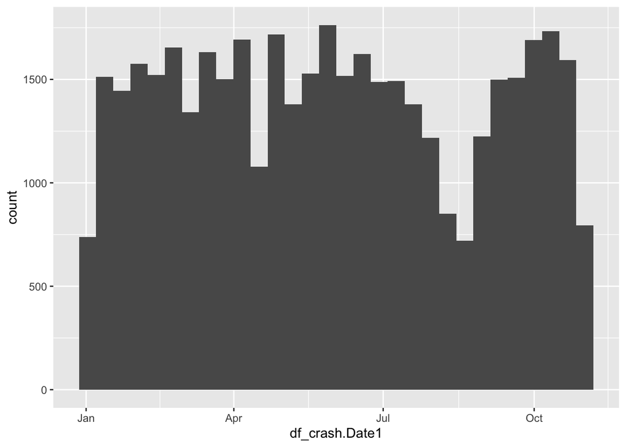

```r
ggplot(df_crashF, aes(x=df_crash.Date1)) + geom_histogram()
```

- La viusalización de los datos muestra ciertos picos (e.g. mid-Feb, Marzo, principios de Abril, Junio, Julio y Septiembre) y bajos (enero, Agosto) en los accidentes de tránsito.
- Esto sugiere claramente en un componente estacional (e.g. Agosto) en cuanto a la flota de vehiculos transitando la ciudad en un dia especifico.
- Un analisis más detallado, sin embargo, pudiera arrojar mayor información sobre periodos/dias especificos más propensos a que hayan accidentes.

```r
#Creando una df con columna Date1
fecha <- df_crashF$df_crash.Date1
#Agregando columna fecha for unique values y guardando
fecha2 <- aggregate(data.frame(count = fecha), list(value = fecha), length)
#Ordenando de manera descendente
head(fecha2[order(-fecha2$count),], n = 10)
```

```
##          value count
## 95  2019-04-05   272
## 151 2019-05-31   238
## 114 2019-04-24   234
## 32  2019-02-01   229
## 53  2019-02-22   211
## 19  2019-01-19   210
## 277 2019-10-04   209
## 304 2019-10-31   206
## 116 2019-04-26   202
## 51  2019-02-20   200
```

##### Y en términos de dias de la semana? los fines de semana son más fatales?

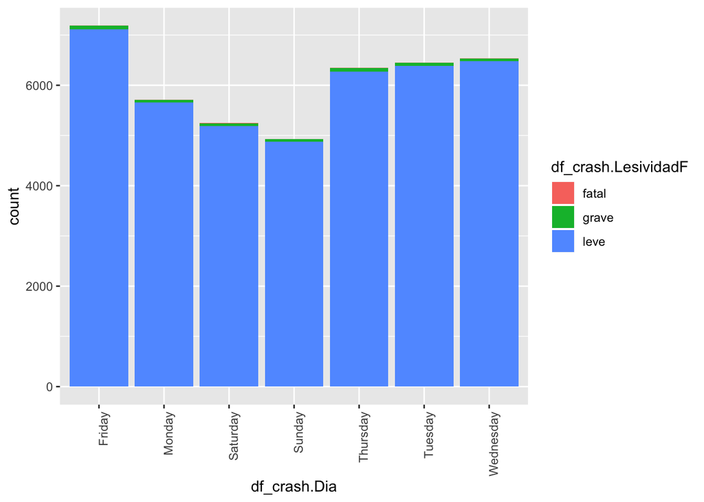

```r
q2 <- ggplot(data=df_crashF[1:filas,], aes(x=df_crash.Dia, fill=df_crash.LesividadF))+geom_bar()
q2 + theme(axis.text.x = element_text(angle = 90, hjust = 1))
```

```r
#Tablas de Frecuenca
f1<-table(df_crashF[1:filas,]$df_crash.Dia, df_crashF[1:filas,]$df_crash.LesividadF)

f<-table(df_crashF[1:filas,]$df_crash.Dia, df_crashF[1:filas,]$df_crash.LesividadF)
for (i in 1:dim(f)[1]){
    f[i,]<-f[i,]/sum(f[i,])*100
}
f
```

```
##
##                   fatal       grave        leve
##   Friday     0.04174784  1.01586418 98.94238798
##   Monday     0.05252101  0.89285714 99.05462185
##   Saturday   0.11426395  1.02837555 98.85736050
##   Sunday     0.02027986  1.15595214 98.82376800
##   Thursday   0.07880221  1.02442868 98.89676911
##   Tuesday    0.04650442  1.03859867 98.91489692
##   Wednesday  0.07652280  0.76522804 99.15824916
```

```r
f1
```

```
##
##             fatal grave leve
##   Friday        3    73 7110
##   Monday        3    51 5658
##   Saturday      6    54 5191
##   Sunday        1    57 4873
##   Thursday      5    65 6275
##   Tuesday       3    67 6381
##   Wednesday     5    50 6479
```

- Consistente con los datos anteriores (por fecha), la visualización confirma que los viernes son los dias de la semana donde han ocurrido más accidentes en el 2019, en torno al 16% de todas las obersvaciones.
- Sin embargo, en términos de grado de lesividad, los sábados son los dias donde han ocurrido más accidentes con fallecidos (6 de 26), seguido por los Jueves (5) y los miércoles (5).

##### En cuál estación del año ha habido más accidentes de transito?

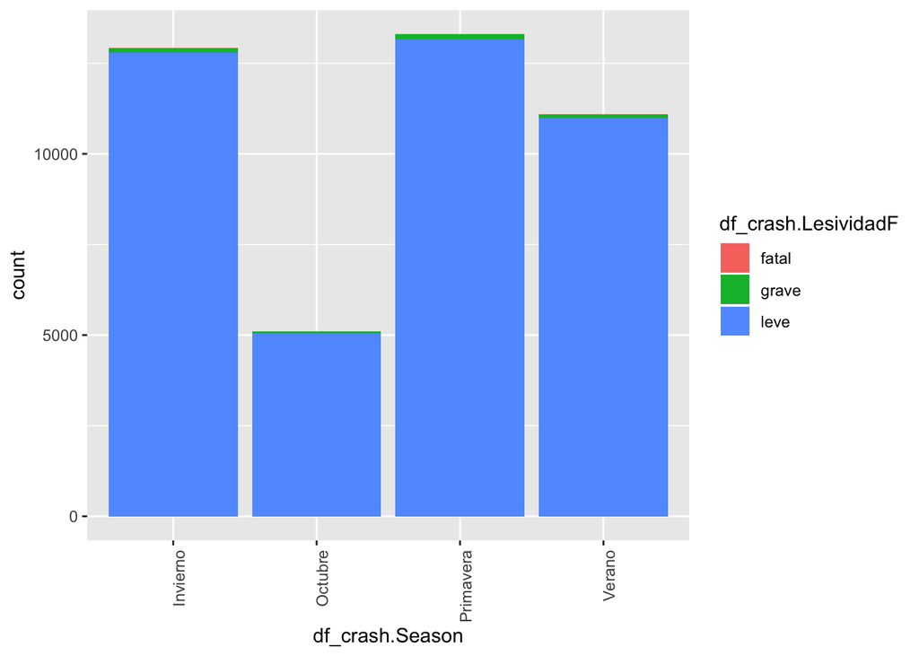

```r
q3 <- ggplot(data=df_crashF[1:filas,], aes(x=df_crash.Season, fill=df_crash.LesividadF))+geom_bar()
q3 + theme(axis.text.x = element_text(angle = 90, hjust = 1))
```

```r
#Tabla de Frecuenca
f2<-table(df_crashF[1:filas,]$df_crash.Season, df_crashF[1:filas,]$df_crash.LesividadF)
f2
```

```
##
##             fatal grave  leve
##   Invierno     10   116 12796
##   Octubre       2    55  5040
##   Primavera     4   148 13152
##   Verano       10    98 10979
```

- En la primavera es donde ocurrieron más accidentes en Madrid, seguido por el invierno.
- La relativa baja frecuencia de verano es probable que este relacionada a factores estacionales.

#### Condiciones Meteorológicas

Cómo influye el tiempo en los accidentes de tránsito? Y en el número de fallecidos?

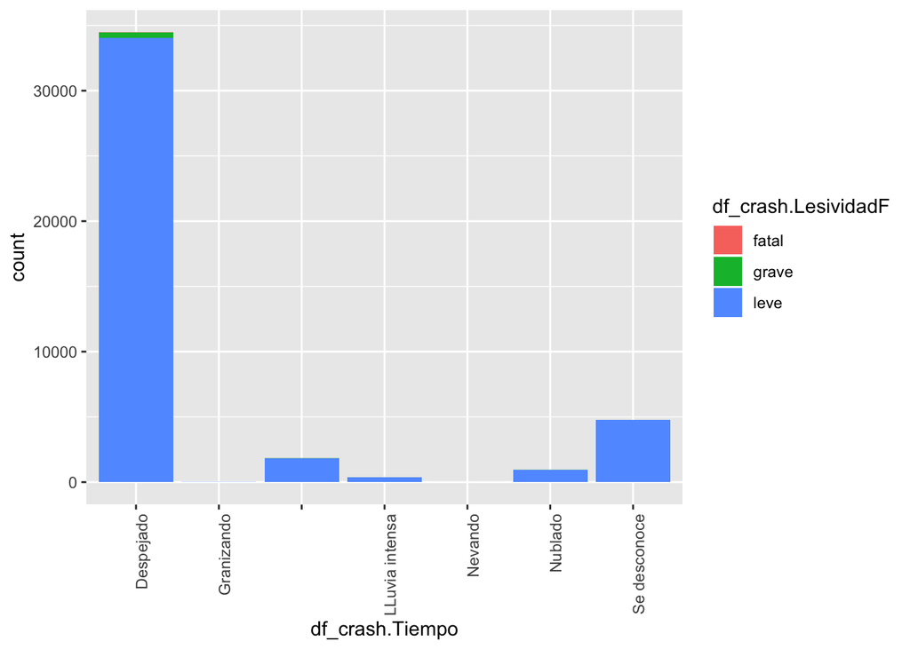

```r
q4 <- ggplot(data=df_crashF[1:filas,], aes(x=df_crash.Tiempo, fill=df_crash.LesividadF))+geom_bar()
q4 + theme(axis.text.x = element_text(angle = 90, hjust = 1))
```

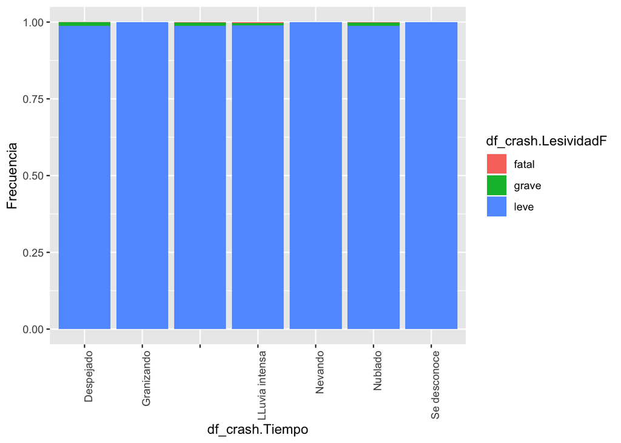

```r
q5 <- ggplot(data=df_crashF[1:filas,], aes(x=df_crash.Tiempo, fill=df_crash.LesividadF))+geom_bar(position="fill")+ylab("Frecuencia")
q5 + theme(axis.text.x = element_text(angle = 90, hjust = 1))
```

```r
#Tablas de Frecuenca
f3<-table(df_crashF[1:filas,]$df_crash.Tiempo, df_crashF[1:filas,]$df_crash.LesividadF)

f4<-table(df_crashF[1:filas,]$df_crash.Tiempo, df_crashF[1:filas,]$df_crash.LesividadF)
for (i in 1:dim(f4)[1]){
    f4[i,]<-f4[i,]/sum(f4[i,])*100
}
f3
```

```
##
##                   fatal grave  leve
##   Despejado          21   384 34062
##   Granizando          0     0    14
##   Lluvia d\xe9bil     3    19  1803
##   LLuvia intensa      1     3   373
##   Nevando             0     0     2
##   Nublado             1    11   931
##   Se desconoce        0     0  4782
```

```r
f4
```

```
##
##                          fatal        grave         leve
##   Despejado         0.06092784   1.11410915  98.82496301
##   Granizando        0.00000000   0.00000000 100.00000000
##   Lluvia d\xe9bil   0.16438356   1.04109589  98.79452055
##   LLuvia intensa    0.26525199   0.79575597  98.93899204
##   Nevando           0.00000000   0.00000000 100.00000000
##   Nublado           0.10604454   1.16648993  98.72746554
##   Se desconoce      0.00000000   0.00000000 100.00000000
```

- Los accidentes han ocurrido mayoritariamente en condiciones de tiempo despejado: a priori, no se observa una gran incidencia de condiciones de tiempo adversas (e.g. lluvia intensa, granizo) en el número de accidentes.
- Sin embargo, el análisis se debe ampliar para incluir condiciones metereológicas mas detalladas.

#### Tipo de Vehículo

Cuál tipo de vehículo es más propenso a accidentes? relación con grado de lesividad

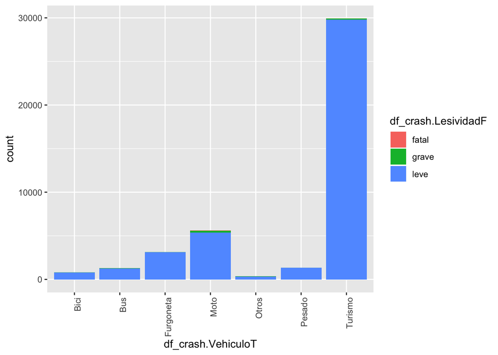

```r
q6 <- ggplot(data=df_crashF[1:filas,], aes(x=df_crash.VehiculoT, fill=df_crash.LesividadF))+geom_bar()
q6 + theme(axis.text.x = element_text(angle = 90, hjust = 1))
```

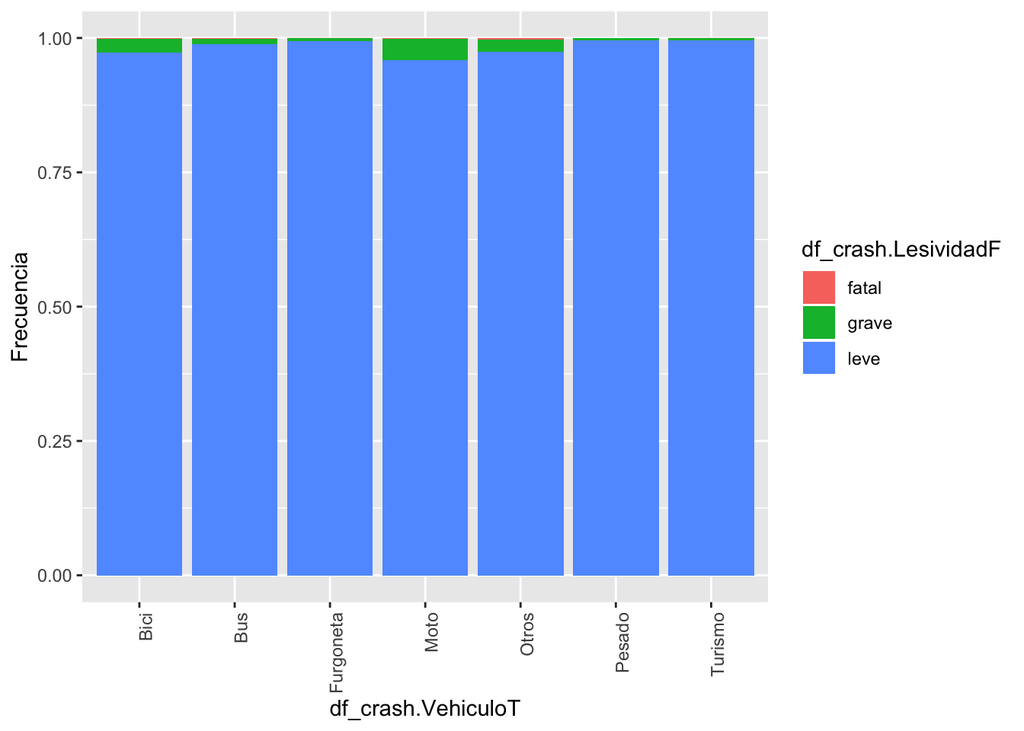

```r
q7 <- ggplot(data=df_crashF[1:filas,], aes(x=df_crash.VehiculoT, fill=df_crash.LesividadF))+geom_bar(position="fill")+ylab("Frecuencia")
q7 + theme(axis.text.x = element_text(angle = 90, hjust = 1))
```

```r
#Tablas de Frecuenca
f5<-table(df_crashF[1:filas,]$df_crash.VehiculoT, df_crashF[1:filas,]$df_crash.LesividadF)

f6<-table(df_crashF[1:filas,]$df_crash.VehiculoT, df_crashF[1:filas,]$df_crash.LesividadF)
for (i in 1:dim(f6)[1]){
    f6[i,]<-f6[i,]/sum(f6[i,])*100
}
f5
```

```
##
##             fatal grave  leve
##   Bici          1    21   773
##   Bus           2    13  1267
##   Furgoneta     1    17  3111
##   Moto         12   220  5375
##   Otros         1     8   335
##   Pesado        0     5  1317
##   Turismo       9   133 29789
```

- Los coches particulares son los que han predominado en los accidentes de tránsito en Madrid en el 2019.
- Sin embargo, los accidentes con fallecidos han sido principalmente con motocicletas (12 de 26), asi como los accidentes con lesividad ‘grave’ (220 de 417).
- Solo ha ocurrido 1 accidente con fallecido en bicicleta; la gran mayoria de los accidentes con bicis son leves.
- Asi mismo, solo 2 accidentes implicando buses (de un total de 1.282) resultaron en fallecidos.

#### Tipo de Persona y Grupos de Edad

##### Cuáles grupos de edades han sufrido más accidentes? en cuáles grupos hay mayor incidencia de fallecimiento?

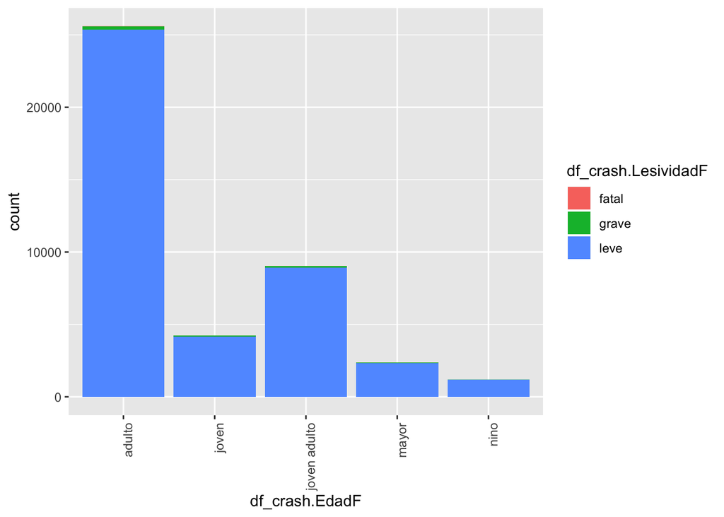

```r
q8 <- ggplot(data=df_crashF[1:filas,], aes(x=df_crash.EdadF, fill=df_crash.LesividadF))+geom_bar()
q8 + theme(axis.text.x = element_text(angle = 90, hjust = 1))
```

```r
#Tablas de Frecuenca
f7<-table(df_crashF[1:filas,]$df_crash.EdadF, df_crashF[1:filas,]$df_crash.LesividadF)

f7
```

```
##
##                fatal grave  leve
##   adulto          16   195 25373
##   joven            2    50  4168
##   joven adulto     4    98  8937
##   mayor            4    62  2324
##   nino             0    12  1165
```

- El grupo de adultos (35-65) es el que ha sufrido mas accidentes de tránsito en el 2019, independientemente del grado de lesividad.
- Se debe comparar con datos mas detallados de individuos empadronados en Madrid con coche (incluyendo edad, sexo) para medir en términos relativos.

##### Y en términos de sexo?

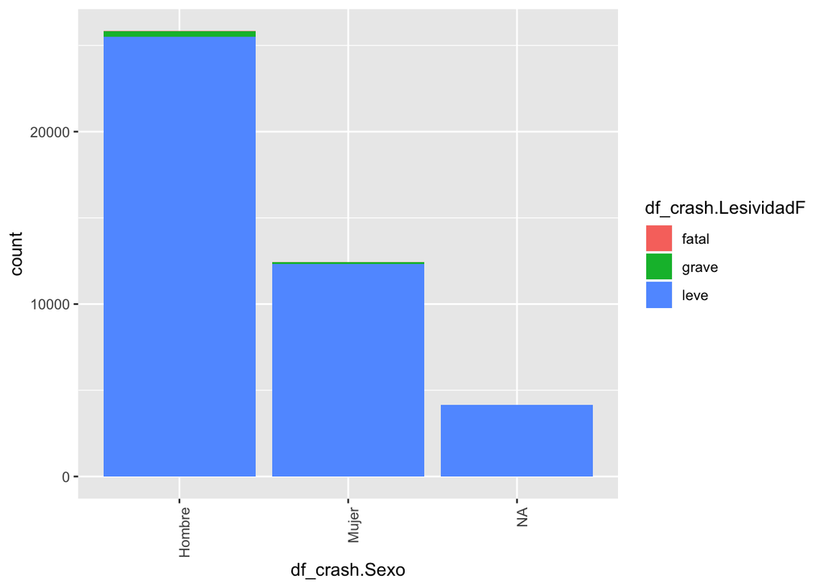

```r
q9 <- ggplot(data=df_crashF[1:filas,], aes(x=df_crash.Sexo, fill=df_crash.LesividadF))+geom_bar()
q9 + theme(axis.text.x = element_text(angle = 90, hjust = 1))
```

```r
#Tablas de Frecuenca
f8<-table(df_crashF[1:filas,]$df_crash.Sexo, df_crashF[1:filas,]$df_crash.LesividadF)

f8
```

```
##
##          fatal grave  leve
##   Hombre    19   302 25504
##   Mujer      7   115 12313
```

- Los hombres han sufrido el doble de accidentes de tránsito que las mujeres en Madrid en el 2019.
- Estas frecuencias relativas se mantienen al considerar el grado de lesividad del accidente.
- Esto puede estar influido por la cantidad de hombres conductores en Madrid (i.e. cual es el porcentaje de la flota de vehiculos conducida por hombres vs. mujeres?)

##### Qué tipo de persona (e.g. conductor, testigo) es el más expuestos? En términos de testigo: cuántos han resultado en fallecimiento?

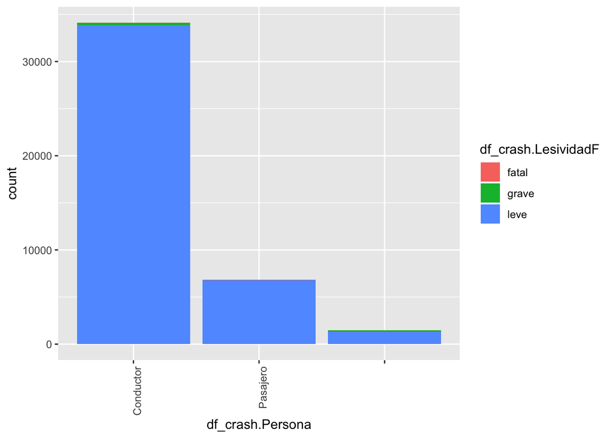

```r
q10 <- ggplot(data=df_crashF[1:filas,], aes(x=df_crash.Persona, fill=df_crash.LesividadF))+geom_bar()
q10 + theme(axis.text.x = element_text(angle = 90, hjust = 1))
```

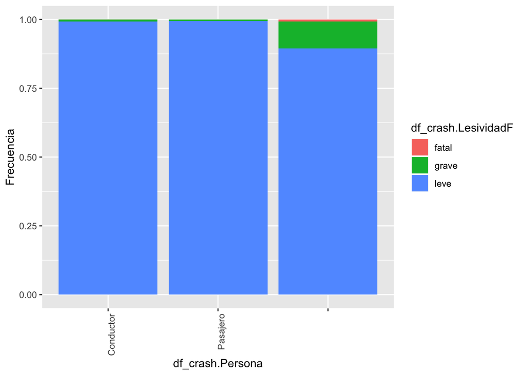

```r
q11 <- ggplot(data=df_crashF[1:filas,], aes(x=df_crash.Persona, fill=df_crash.LesividadF))+geom_bar(position="fill")+ylab("Frecuencia")
q11 + theme(axis.text.x = element_text(angle = 90, hjust = 1))
```

```r
#Tablas de Frecuenca
f9<-table(df_crashF[1:filas,]$df_crash.Persona, df_crashF[1:filas,]$df_crash.LesividadF)

f9
```

```
##
##             fatal grave  leve
##   Conductor    14   235 33870
##   Pasajero      1    37  6781
##   Peat\xf3n    11   145  1316
```

*Los accidentes de tránsito tendieron a incluir mayoritariamente al conductor del vehículo: menos del 20% de las observaciones implicaron pasajeros o peatones.* Sin embargo, la proporsión de accidentes fatales y graves respecto al total implicando a peatones tendieron a ser relativamente mayores versus otros tipos de persona

### 10. Conclusiones y Sugerencias

La exploración confirma que la base de datos puede ser de gran valor para diferentes entidades, incluyendo peatones, conductores, cuerpos policiales, de atención médica, prestadores de servicios de vehiculos de alquiler, empresas de seguro.

Para su mejor explotación se sugiere la ampliación con base de datos que incluyan:

- Condiciones metereológicas más detalladas.
- Flota de cuerpos policiales (incluyendo tránsito) por distrito, fecha y hora.
- Centros de atención médica por distrito, incluyendo atención de emergencia.
- Características de individuos empadronados en Madrid con coche, para entender mejor proporciones en terminos de sexo y grupos de edad.
- Asi mismo, características de los vehículos registrados.
- La base de dato se debe cruzar con dummies de calendario: dias festivos, eventos especiales, entre otros.